# Classification

2025-09-03

## The Plan

- Overview
- Logistic Regression
- Bayes’ Theorem
- LDA
- Naive Bayes

## Classification

- Recall that a “classification” model is a supervised model where the response variable is *categorical*.
  - Fraud detection
  - Disease diagnosis
  - Species identification

## An Example

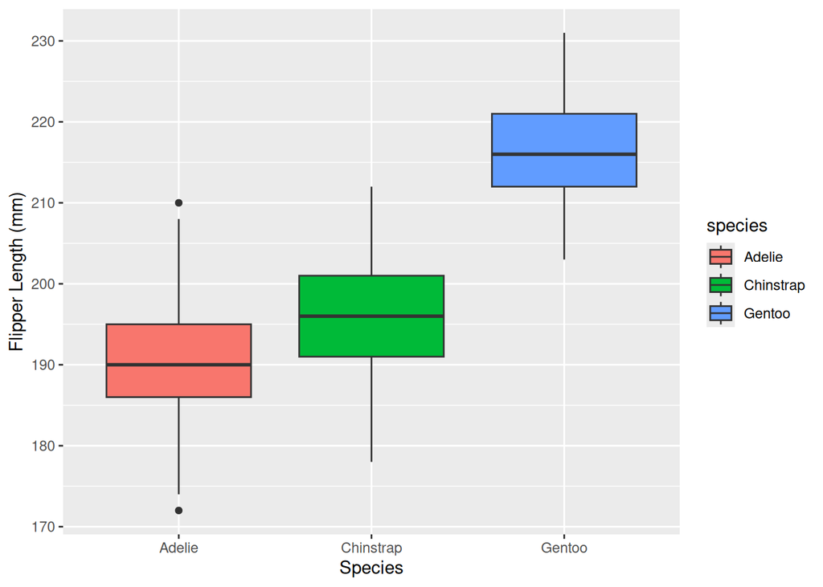

## Body Mass Plot

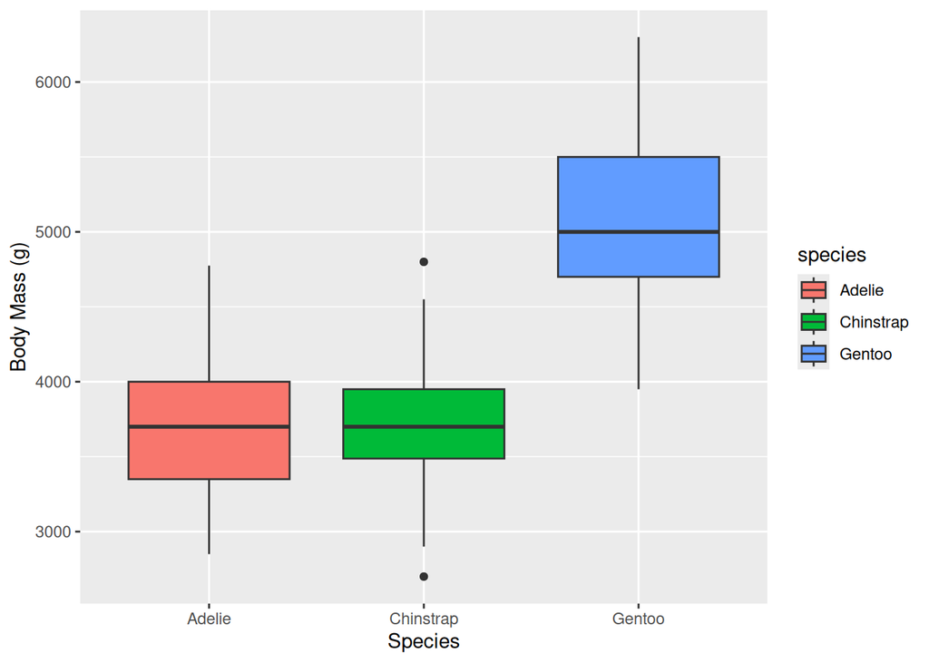

## Logistic Regression

Let \(p_y(X) = Pr(Y=y|X)\) where \(y\) could be any of the values in “species”.

Suppose \[p_y(X) = \frac{e^{\beta_{y0} + \beta_{y1}x_1 + \cdots \beta_{yp}x_p}}{1 + \sum_{l=1}^{K-1} e^{\beta_{l0} + \beta_{l1}x_1 + \cdots \beta_{lp}x_p}}\] and then \[p_K(X) = \frac{1}{1 + \sum_{l=1}^{K-1} e^{\beta_{l0} + \beta_{l1}x_1 + \cdots \beta_{lp}x_p}}\] Using some high school math, we can see that \[\log(\frac{p_y(X)}{p_K(X)}) = \beta_{y0} + \beta_{y1}x_1 + \cdots + \beta_{yp}x_p\]

## Maximum Likelihood

The *likelihood* function

\[ l(\mathbf{\beta}) = \prod_{i: y_i =1} p(x_i) \prod_{i: y_i = 0} (1 - p(x_i))\]

The *maximum likelihood* is the set of parameters \(\beta\) that maximize this likelihood function.

## With the Penguin Data

```
## Call:
## multinom(formula = species ~ flipper_length_mm + body_mass_g,
##     data = penguins, family = "multinomial")
##
## Coefficients:
##           (Intercept) flipper_length_mm  body_mass_g
## Chinstrap   -31.26682         0.1829957 -0.001303130
## Gentoo     -148.36586         0.6534390  0.003295482
##
## Std. Errors:
##            (Intercept) flipper_length_mm  body_mass_g
## Chinstrap 6.768461e-05       0.008237114 0.0004277966
## Gentoo    1.375134e-04       0.031403516 0.0015044244
##
## Residual Deviance: 268.7316
## AIC: 280.7316
```

## Multinomial Logistic Regression Tests

```
##           (Intercept) flipper_length_mm body_mass_g
## Chinstrap   -461948.7          22.21600   -3.046143
## Gentoo     -1078918.9          20.80783    2.190527
```

Z-Test

```
##           (Intercept) flipper_length_mm body_mass_g
## Chinstrap           0                 0 0.002317977
## Gentoo              0                 0 0.028486066
```

## Predicted Probabilities

```r
pp <- fitted(logreg)
head(pp)
```

```
##      Adelie  Chinstrap       Gentoo
## 1 0.9539694 0.04603057 1.893114e-08
## 2 0.8985757 0.10142376 5.516737e-07
## 3 0.4545733 0.54541041 1.631665e-05
## 5 0.6093090 0.39067953 1.144291e-05
## 6 0.7779973 0.22199877 3.977078e-06
## 7 0.9462638 0.05373619 1.243808e-08
```

## Adding a Factor

```
## Call:
## multinom(formula = species ~ flipper_length_mm + body_mass_g +
##     factor(island), data = penguins, family = "multinomial")
##
## Coefficients:
##           (Intercept) flipper_length_mm  body_mass_g factor(island)Dream
## Chinstrap   -44.04919         0.1741401 -0.001333458            15.61348
## Gentoo     -425.67513         2.2283922 -0.005735040           -55.34559
##           factor(island)Torgersen
## Chinstrap               -5.434683
## Gentoo                 -33.905130
##
## Std. Errors:
##            (Intercept) flipper_length_mm  body_mass_g factor(island)Dream
## Chinstrap 6.509584e-05         0.0112689 0.0005851058        6.509581e-05
## Gentoo    7.585096e-04         0.1381188 0.0060842474        1.525027e-17
##           factor(island)Torgersen
## Chinstrap            4.798475e-13
## Gentoo               4.272442e-08
##
## Residual Deviance: 145.6996
## AIC: 165.6996
```

## Model Tests

```
##           (Intercept) flipper_length_mm body_mass_g factor(island)Dream
## Chinstrap   -676682.0          15.45316  -2.2790029        2.398539e+05
## Gentoo      -561199.4          16.13389  -0.9426047       -3.629154e+18
##           factor(island)Torgersen
## Chinstrap           -1.132586e+13
## Gentoo              -7.935772e+08
```

Z-test

```
##           (Intercept) flipper_length_mm body_mass_g factor(island)Dream
## Chinstrap           0                 0  0.02266689                   0
## Gentoo              0                 0  0.34588314                   0
##           factor(island)Torgersen
## Chinstrap                       0
## Gentoo                          0
```

## Predicted Probabilities

```r
pp <- fitted(logreg2)
tail(pp)
```

```
##         Adelie Chinstrap       Gentoo
## 339 0.34197599 0.6580240 1.799317e-30
## 340 0.09300596 0.9069940 2.699109e-20
## 341 0.09913737 0.9008626 1.301585e-23
## 342 0.46517190 0.5348281 1.386218e-32
## 343 0.06497644 0.9350236 8.506117e-18
## 344 0.26693307 0.7330669 5.489246e-28
```

## Bayes Theorem

\[P(A | B) = \frac{P(B|A)P(A)}{P(B)} = \frac{P(B|A)P(A)}{P(B|A)P(A) + P(B|A^c)P(A^c)}\]

Example:

Suppose a Really Bad Disease (RBD) occurs in \(10^{-6}\) patients. There is a test for RBD that is 99% effective (which we will take to mean that there are 1% false positives and 1% false negatives). If a patient tests positive for RBD, what’s the probability that they have the disease?

## Linear Discriminant Analysis (LDA)

Using Bayes’ to estimate \[P(Y=k|X=x) = \frac{P(X=x|Y=k)P(Y=k)}{P(X=x)}\] (notice the denominator does *not* depend on \(k\)).

LDA assumes data from *all* classes comes from a multivariate normal distribution with a common covariance:

\[p(X=x | Y=k) = \frac{1}{(2\pi)^{p/2}|\Sigma|^{1/2}} e^{-\frac{1}{2}(x - \mu_k)^T \Sigma^{-1}(x-\mu_k)}\]

Or the log form:

\[ \delta_k(x) = x^T \Sigma^{-1} \mu_k + \mu_k \Sigma^{-1} \mu_k + \log(\pi_k)\]

The k for which \(\delta_k(x)\) is largest is the class label for \(x\).

## Fitting LDA

One can empirically set \[\mu_k = \frac{1}{N_k}\sum_{i: y_i=k} x_i\]

and

\[ \Sigma = \frac{1}{N - K}\sum_{k=1}^K \sum_{i:y_i=k} (x_i - \mu_i)^T(x_i - \mu_i)\]

and

\[\pi_k = \frac{N_K}{N}\]

## Naive Bayes

Naive Bayes is *similar* to LDA, but the distributions \[f_k(x) := p(X=x|Y=k)\]

Are assumed to be independent, so \[ f_k(x) = \prod_{j=1}^p f_{k,j}(x_j) \]

These one-dimensional distributions can be estimated using *Kernel Density Estimation*(KDE)

## KDE

Choose a one-dimensional distribution:

1. Uniform
2. Normal
3. Semicircular
4. …

\[f(x) = \frac{1}{N*h} \sum_{j=1}^N f(\frac{x}{h})\]